# Chronic Conditions and Healthcare Utilisation in the United States

Published

March 20, 2026

## Introduction

Chronic conditions represent a significant burden on healthcare systems. This report investigates whether patients with chronic conditions differ from healthy patients in terms of encounter frequency, encounter types, racial distribution, geographic spread, and mortality.

**Research Question:** *Do patients with chronic conditions such as diabetes/hypertension differ from healthy patients in terms of healthcare encounter frequency, encounter types, racial distribution, geographic distribution, and mortality?*

## 1. Data and Methods

Three synthetic datasets from the Synthea health record generator were linked using patient ID. A patient was classified as chronic if they had a long term lifestyle condition containing the terms diabetes or hypertension.

- **6,851** total patients
- **3,159** (46%) identified as having a chronic condition
- Zero orphaned records confirmed across all datasets

## 2. Healthcare Encounter Frequency

### Summary Statistics

| Group | Gender | N | Mean Encounters | Median Encounters | Mean Age |
| --- | --- | --- | --- | --- | --- |
| Chronic | F | 1,550 | 233.6 | 199 | 60.2 |
| Chronic | M | 1,609 | 189.4 | 124 | 62.2 |
| Healthy | F | 1,908 | 91.9 | 64 | 28.4 |
| Healthy | M | 1,784 | 65.3 | 50 | 29.7 |

### Encounters by Condition Status

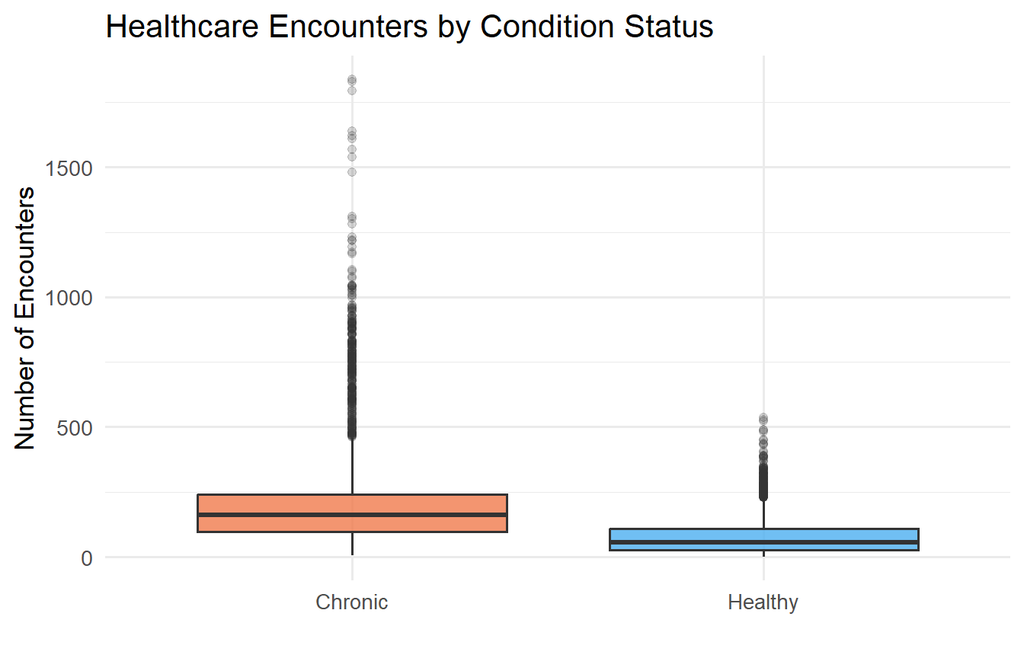

### Encounters by Gender

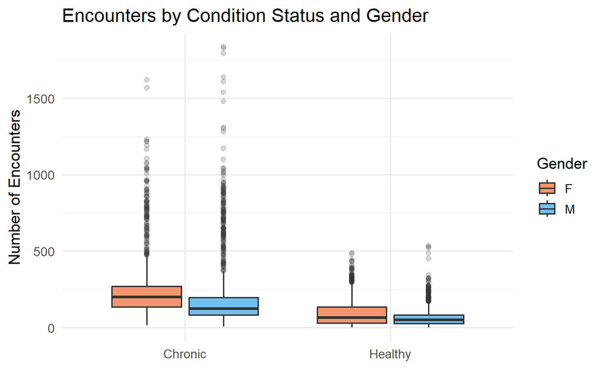

### Encounters by Age Group

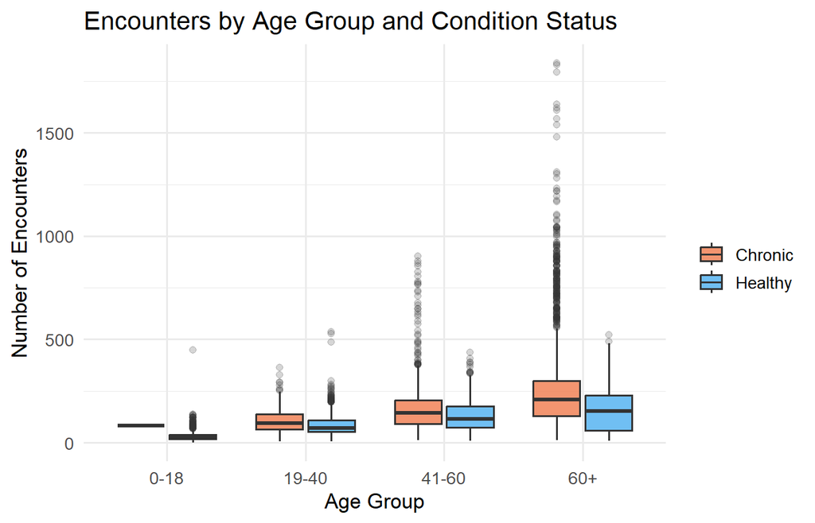

## 3. Types of Healthcare Encounters

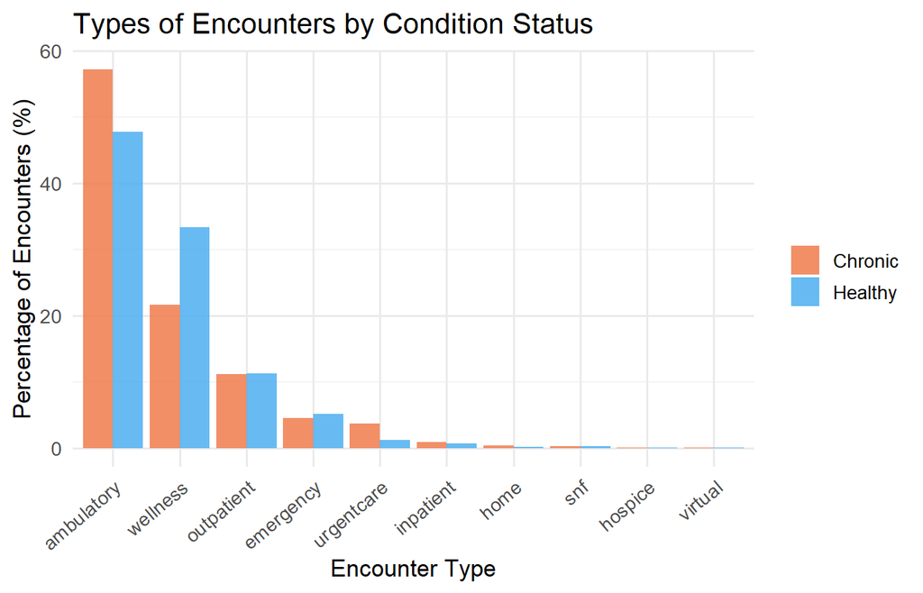

## 4. Racial Distribution

| Race | Total Patients | Chronic Patients | % Chronic |
| --- | --- | --- | --- |
| hawaiian | 138 | 69 | 50.0 |
| black | 819 | 408 | 49.8 |
| white | 5,155 | 2,361 | 45.8 |
| asian | 352 | 161 | 45.7 |
| other | 133 | 58 | 43.6 |
| native | 254 | 102 | 40.2 |

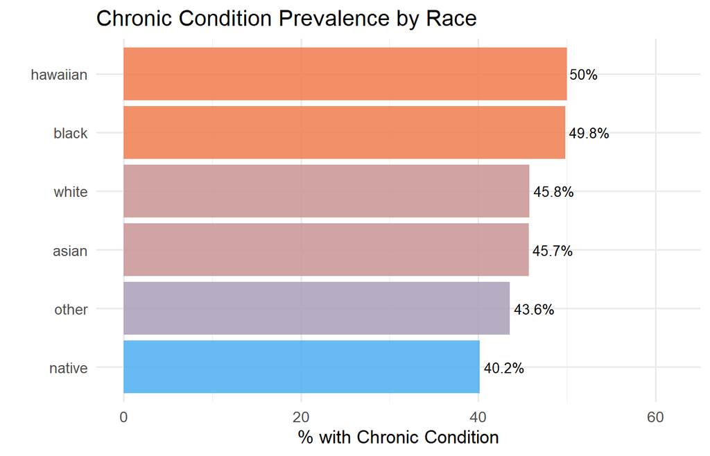

## 5. Geographic Distribution by State

### Interactive Patient Map

[interactive chart not shown]

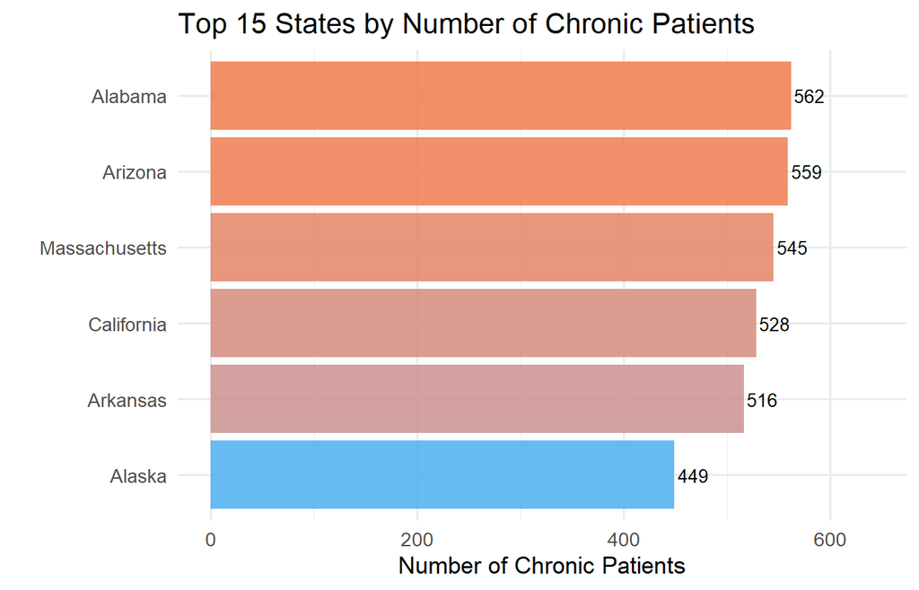

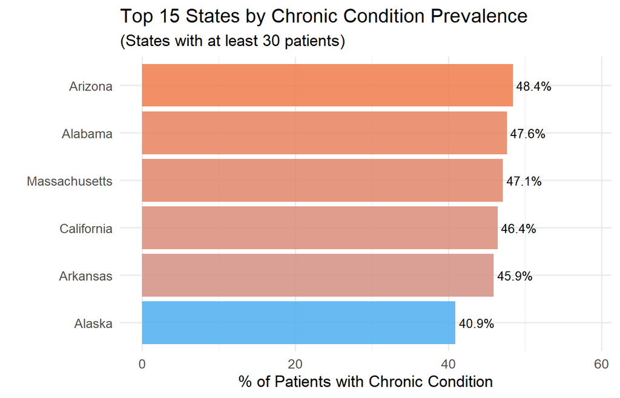

## 6. Mortality by Condition Status

| Group | Total Patients | Deceased | % Deceased |
| --- | --- | --- | --- |
| Chronic | 3,159 | 574 | 18.2 |
| Healthy | 3,692 | 277 | 7.5 |

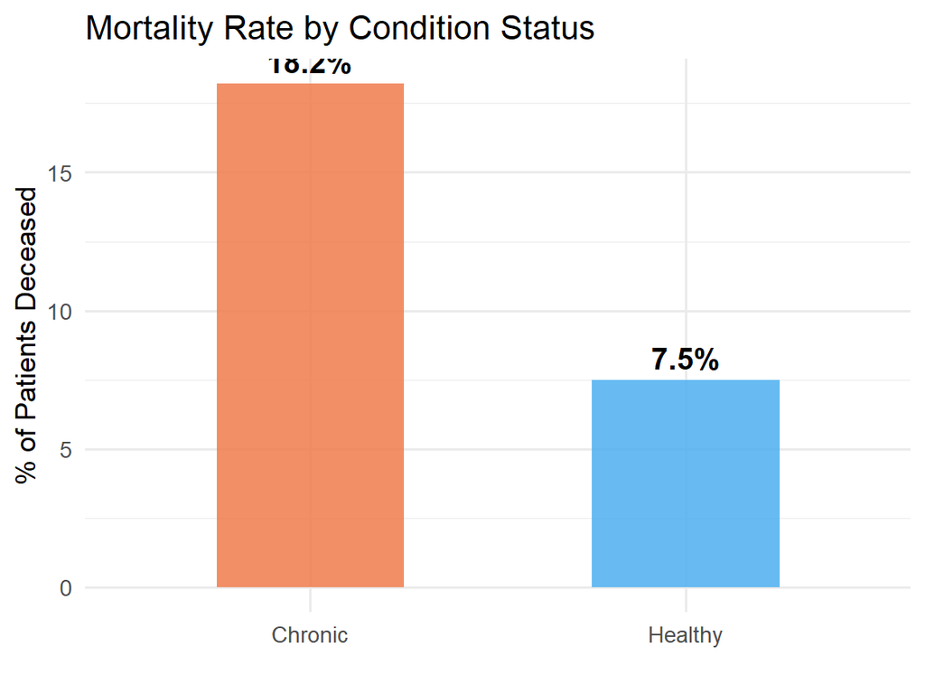

## 7. Statistical Tests

| Test | Statistic | P-Value | Conclusion |
| --- | --- | --- | --- |
| Wilcoxon rank-sum (encounter frequency) | 9,347,323.000 | < 2.2e-16 | Significant difference in encounter frequency |
| Chi-square (mortality vs chronic status) | 177.102 | < 2.2e-16 | Significant association with mortality |

Both tests returned p-values below 0.05, confirming statistically significant differences between chronic and healthy patients.